# Risk Factor Analysis

## Outcome Variable

**Outcome Variable:** wast_rec90d

## Predictor Variables

**Intervention Variable:** feducyrs

**Adjustment Set:**

- arm
- W_mage
- meducyrs
- hhwealth_quart
- W_mhtcm
- W_mwtkg
- W_mbmi
- W_gagebrth
- W_birthwt
- W_birthlen
- single
- delta_W_mage
- delta_meducyrs
- delta_hhwealth_quart
- delta_W_mhtcm
- delta_W_mwtkg
- delta_W_mbmi
- delta_W_gagebrth
- delta_W_birthwt
- delta_W_birthlen
- delta_single

## Stratifying Variables

The analysis was stratified on these variable(s):

- agecat
- studyid
- country

## Data Summary

| agecat | studyid | country | feducyrs | wast_rec90d | n_cell | n |
| --- | --- | --- | --- | --- | --- | --- |
| 0-24 months | COHORTS | GUATEMALA | High | 0 | 37 | 358 |
| 0-24 months | COHORTS | GUATEMALA | High | 1 | 38 | 358 |
| 0-24 months | COHORTS | GUATEMALA | Low | 0 | 88 | 358 |
| 0-24 months | COHORTS | GUATEMALA | Low | 1 | 71 | 358 |
| 0-24 months | COHORTS | GUATEMALA | Medium | 0 | 74 | 358 |
| 0-24 months | COHORTS | GUATEMALA | Medium | 1 | 50 | 358 |
| 0-24 months | COHORTS | INDIA | High | 0 | 143 | 539 |
| 0-24 months | COHORTS | INDIA | High | 1 | 50 | 539 |
| 0-24 months | COHORTS | INDIA | Low | 0 | 152 | 539 |
| 0-24 months | COHORTS | INDIA | Low | 1 | 34 | 539 |
| 0-24 months | COHORTS | INDIA | Medium | 0 | 106 | 539 |
| 0-24 months | COHORTS | INDIA | Medium | 1 | 54 | 539 |
| 0-24 months | COHORTS | PHILIPPINES | High | 0 | 174 | 1574 |
| 0-24 months | COHORTS | PHILIPPINES | High | 1 | 336 | 1574 |
| 0-24 months | COHORTS | PHILIPPINES | Low | 0 | 214 | 1574 |
| 0-24 months | COHORTS | PHILIPPINES | Low | 1 | 281 | 1574 |
| 0-24 months | COHORTS | PHILIPPINES | Medium | 0 | 227 | 1574 |
| 0-24 months | COHORTS | PHILIPPINES | Medium | 1 | 342 | 1574 |
| 0-24 months | GMS-Nepal | NEPAL | High | 0 | 77 | 641 |
| 0-24 months | GMS-Nepal | NEPAL | High | 1 | 79 | 641 |
| 0-24 months | GMS-Nepal | NEPAL | Low | 0 | 127 | 641 |
| 0-24 months | GMS-Nepal | NEPAL | Low | 1 | 141 | 641 |
| 0-24 months | GMS-Nepal | NEPAL | Medium | 0 | 91 | 641 |
| 0-24 months | GMS-Nepal | NEPAL | Medium | 1 | 126 | 641 |
| 0-24 months | JiVitA-3 | BANGLADESH | High | 0 | 905 | 7280 |
| 0-24 months | JiVitA-3 | BANGLADESH | High | 1 | 797 | 7280 |
| 0-24 months | JiVitA-3 | BANGLADESH | Low | 0 | 1846 | 7280 |
| 0-24 months | JiVitA-3 | BANGLADESH | Low | 1 | 1242 | 7280 |
| 0-24 months | JiVitA-3 | BANGLADESH | Medium | 0 | 1449 | 7280 |
| 0-24 months | JiVitA-3 | BANGLADESH | Medium | 1 | 1041 | 7280 |

[output cut: 330 more lines]

The following strata were considered:

- agecat: 0-24 months, studyid: COHORTS, country: GUATEMALA
- agecat: 0-24 months, studyid: COHORTS, country: INDIA
- agecat: 0-24 months, studyid: COHORTS, country: PHILIPPINES
- agecat: 0-24 months, studyid: GMS-Nepal, country: NEPAL
- agecat: 0-24 months, studyid: JiVitA-3, country: BANGLADESH
- agecat: 0-24 months, studyid: JiVitA-4, country: BANGLADESH
- agecat: 0-24 months, studyid: LCNI-5, country: MALAWI
- agecat: 0-24 months, studyid: MAL-ED, country: BANGLADESH
- agecat: 0-24 months, studyid: MAL-ED, country: INDIA
- agecat: 0-24 months, studyid: MAL-ED, country: NEPAL
- agecat: 0-24 months, studyid: MAL-ED, country: PERU
- agecat: 0-24 months, studyid: MAL-ED, country: SOUTH AFRICA
- agecat: 0-24 months, studyid: MAL-ED, country: TANZANIA, UNITED REPUBLIC OF
- agecat: 0-24 months, studyid: NIH-Crypto, country: BANGLADESH
- agecat: 0-24 months, studyid: PROBIT, country: BELARUS
- agecat: 0-24 months, studyid: PROVIDE, country: BANGLADESH
- agecat: 0-24 months, studyid: SAS-CompFeed, country: INDIA
- agecat: 0-24 months, studyid: SAS-FoodSuppl, country: INDIA
- agecat: 0-24 months, studyid: TanzaniaChild2, country: TANZANIA, UNITED REPUBLIC OF
- agecat: 0-24 months, studyid: ZVITAMBO, country: ZIMBABWE
- agecat: 0-6 months, studyid: COHORTS, country: GUATEMALA
- agecat: 0-6 months, studyid: COHORTS, country: INDIA
- agecat: 0-6 months, studyid: COHORTS, country: PHILIPPINES
- agecat: 0-6 months, studyid: GMS-Nepal, country: NEPAL
- agecat: 0-6 months, studyid: JiVitA-3, country: BANGLADESH
- agecat: 0-6 months, studyid: JiVitA-4, country: BANGLADESH
- agecat: 0-6 months, studyid: LCNI-5, country: MALAWI
- agecat: 0-6 months, studyid: MAL-ED, country: BANGLADESH
- agecat: 0-6 months, studyid: MAL-ED, country: INDIA
- agecat: 0-6 months, studyid: MAL-ED, country: NEPAL
- agecat: 0-6 months, studyid: MAL-ED, country: PERU
- agecat: 0-6 months, studyid: MAL-ED, country: SOUTH AFRICA
- agecat: 0-6 months, studyid: MAL-ED, country: TANZANIA, UNITED REPUBLIC OF
- agecat: 0-6 months, studyid: NIH-Crypto, country: BANGLADESH
- agecat: 0-6 months, studyid: PROBIT, country: BELARUS
- agecat: 0-6 months, studyid: PROVIDE, country: BANGLADESH
- agecat: 0-6 months, studyid: SAS-CompFeed, country: INDIA
- agecat: 0-6 months, studyid: SAS-FoodSuppl, country: INDIA
- agecat: 0-6 months, studyid: TanzaniaChild2, country: TANZANIA, UNITED REPUBLIC OF
- agecat: 0-6 months, studyid: ZVITAMBO, country: ZIMBABWE
- agecat: 6-24 months, studyid: COHORTS, country: GUATEMALA
- agecat: 6-24 months, studyid: COHORTS, country: INDIA
- agecat: 6-24 months, studyid: COHORTS, country: PHILIPPINES
- agecat: 6-24 months, studyid: GMS-Nepal, country: NEPAL
- agecat: 6-24 months, studyid: JiVitA-3, country: BANGLADESH
- agecat: 6-24 months, studyid: JiVitA-4, country: BANGLADESH
- agecat: 6-24 months, studyid: LCNI-5, country: MALAWI
- agecat: 6-24 months, studyid: MAL-ED, country: BANGLADESH
- agecat: 6-24 months, studyid: MAL-ED, country: INDIA
- agecat: 6-24 months, studyid: MAL-ED, country: NEPAL
- agecat: 6-24 months, studyid: MAL-ED, country: PERU
- agecat: 6-24 months, studyid: MAL-ED, country: SOUTH AFRICA
- agecat: 6-24 months, studyid: MAL-ED, country: TANZANIA, UNITED REPUBLIC OF
- agecat: 6-24 months, studyid: NIH-Crypto, country: BANGLADESH
- agecat: 6-24 months, studyid: PROBIT, country: BELARUS
- agecat: 6-24 months, studyid: PROVIDE, country: BANGLADESH
- agecat: 6-24 months, studyid: SAS-CompFeed, country: INDIA
- agecat: 6-24 months, studyid: SAS-FoodSuppl, country: INDIA
- agecat: 6-24 months, studyid: TanzaniaChild2, country: TANZANIA, UNITED REPUBLIC OF
- agecat: 6-24 months, studyid: ZVITAMBO, country: ZIMBABWE

### Dropped Strata

Some strata were dropped due to rare outcomes:

- agecat: 0-24 months, studyid: LCNI-5, country: MALAWI
- agecat: 0-24 months, studyid: MAL-ED, country: NEPAL
- agecat: 0-24 months, studyid: MAL-ED, country: PERU
- agecat: 0-24 months, studyid: MAL-ED, country: SOUTH AFRICA
- agecat: 0-24 months, studyid: MAL-ED, country: TANZANIA, UNITED REPUBLIC OF
- agecat: 0-24 months, studyid: SAS-FoodSuppl, country: INDIA
- agecat: 0-6 months, studyid: LCNI-5, country: MALAWI
- agecat: 0-6 months, studyid: MAL-ED, country: BANGLADESH
- agecat: 0-6 months, studyid: MAL-ED, country: INDIA
- agecat: 0-6 months, studyid: MAL-ED, country: NEPAL
- agecat: 0-6 months, studyid: MAL-ED, country: PERU
- agecat: 0-6 months, studyid: MAL-ED, country: SOUTH AFRICA
- agecat: 0-6 months, studyid: MAL-ED, country: TANZANIA, UNITED REPUBLIC OF
- agecat: 0-6 months, studyid: NIH-Crypto, country: BANGLADESH
- agecat: 0-6 months, studyid: SAS-FoodSuppl, country: INDIA
- agecat: 6-24 months, studyid: COHORTS, country: GUATEMALA
- agecat: 6-24 months, studyid: COHORTS, country: INDIA
- agecat: 6-24 months, studyid: JiVitA-3, country: BANGLADESH
- agecat: 6-24 months, studyid: LCNI-5, country: MALAWI
- agecat: 6-24 months, studyid: MAL-ED, country: BANGLADESH
- agecat: 6-24 months, studyid: MAL-ED, country: NEPAL
- agecat: 6-24 months, studyid: MAL-ED, country: PERU
- agecat: 6-24 months, studyid: MAL-ED, country: SOUTH AFRICA
- agecat: 6-24 months, studyid: MAL-ED, country: TANZANIA, UNITED REPUBLIC OF
- agecat: 6-24 months, studyid: NIH-Crypto, country: BANGLADESH
- agecat: 6-24 months, studyid: PROBIT, country: BELARUS
- agecat: 6-24 months, studyid: SAS-FoodSuppl, country: INDIA
- agecat: 6-24 months, studyid: ZVITAMBO, country: ZIMBABWE

## Methods Detail

We’re interested in the causal parameters $E[Y_a]$ for all values of $a \in \mathcal{A}$. These parameters represent the mean outcome if, possibly contrary to fact, we intervened to set all units to have $A=a$. Under the randomization and positivity assumptions, these are identified by the statistical parameters $\psi_a=E_W[E_{Y|A,W}(Y|A=a,W)]$. In addition, we’re interested in the mean of $Y$, $E[Y]$ under no intervention (the observed mean). We will estimate these parameters by using SuperLearner to fit the relevant likelihood factors – $E_{Y|A,W}(Y|A=a,W)$ and $p(A=a|W)$, and then updating our likelihood fit using a joint TMLE.

For unadjusted analyses ($W=\{\}$), initial likelihoods were estimated using Lrnr_glm to estimate the simple $E(Y|A)$ and Lrnr_mean to estimate $p(A)$. For adjusted analyses, a small library containing Lrnr_glmnet, Lrnr_xgboost, and Lrnr_mean was used.

Having estimated these parameters, we will then use the delta method to estimate relative risks and attributable risks relative to a prespecified baseline level of $A$.

# Results Detail

## Results Plots

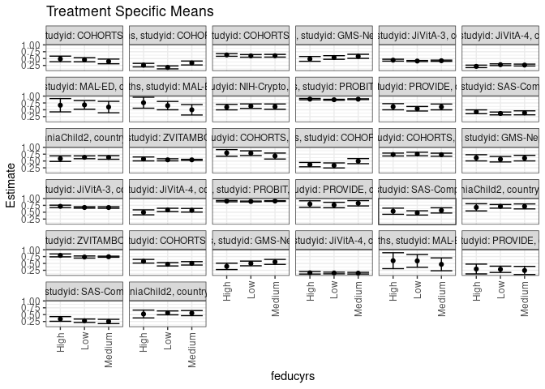

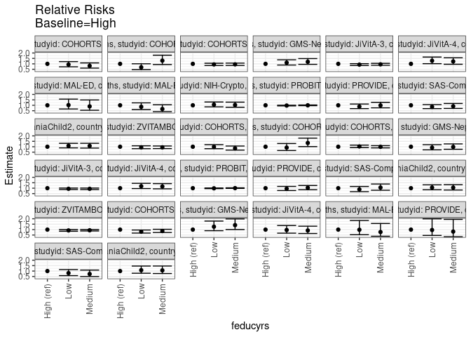

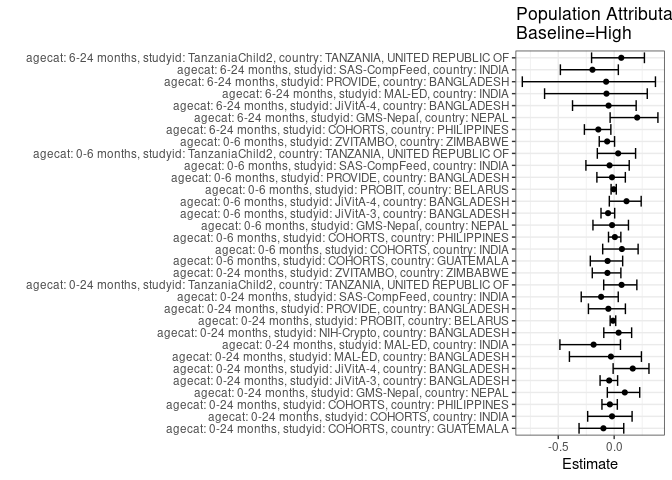

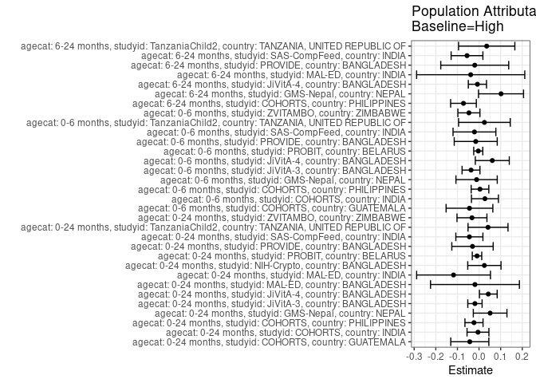

## Results Table

### Parameter: TSM

| agecat | studyid | country | intervention_level | baseline_level | estimate | ci_lower | ci_upper |
| --- | --- | --- | --- | --- | --- | --- | --- |
| 0-24 months | COHORTS | GUATEMALA | High | NA | 0.4868291 | 0.3845569 | 0.5891014 |
| 0-24 months | COHORTS | GUATEMALA | Low | NA | 0.4558400 | 0.3817258 | 0.5299542 |
| 0-24 months | COHORTS | GUATEMALA | Medium | NA | 0.3964361 | 0.3106946 | 0.4821776 |
| 0-24 months | COHORTS | INDIA | High | NA | 0.2609434 | 0.1961837 | 0.3257031 |
| 0-24 months | COHORTS | INDIA | Low | NA | 0.1780925 | 0.1241285 | 0.2320565 |
| 0-24 months | COHORTS | INDIA | Medium | NA | 0.3382649 | 0.2659784 | 0.4105515 |
| 0-24 months | COHORTS | PHILIPPINES | High | NA | 0.6326070 | 0.5845310 | 0.6806831 |
| 0-24 months | COHORTS | PHILIPPINES | Low | NA | 0.5985377 | 0.5505981 | 0.6464774 |
| 0-24 months | COHORTS | PHILIPPINES | Medium | NA | 0.6030667 | 0.5537425 | 0.6523909 |
| 0-24 months | GMS-Nepal | NEPAL | High | NA | 0.4884728 | 0.4004547 | 0.5764910 |
| 0-24 months | GMS-Nepal | NEPAL | Low | NA | 0.5400631 | 0.4743689 | 0.6057572 |
| 0-24 months | GMS-Nepal | NEPAL | Medium | NA | 0.5820356 | 0.5081549 | 0.6559163 |
| 0-24 months | JiVitA-3 | BANGLADESH | High | NA | 0.4419671 | 0.4070959 | 0.4768382 |
| 0-24 months | JiVitA-3 | BANGLADESH | Low | NA | 0.4104253 | 0.3904968 | 0.4303538 |
| 0-24 months | JiVitA-3 | BANGLADESH | Medium | NA | 0.4214719 | 0.3988381 | 0.4441057 |
| 0-24 months | JiVitA-4 | BANGLADESH | High | NA | 0.2152380 | 0.1704387 | 0.2600374 |
| 0-24 months | JiVitA-4 | BANGLADESH | Low | NA | 0.2768504 | 0.2451528 | 0.3085480 |
| 0-24 months | JiVitA-4 | BANGLADESH | Medium | NA | 0.2633821 | 0.2290671 | 0.2976971 |
| 0-24 months | MAL-ED | BANGLADESH | High | NA | 0.6666667 | 0.4235357 | 0.9097976 |
| 0-24 months | MAL-ED | BANGLADESH | Low | NA | 0.6785714 | 0.5198822 | 0.8372607 |
| 0-24 months | MAL-ED | BANGLADESH | Medium | NA | 0.6000000 | 0.3909534 | 0.8090466 |
| 0-24 months | MAL-ED | INDIA | High | NA | 0.7586207 | 0.5584813 | 0.9587601 |
| 0-24 months | MAL-ED | INDIA | Low | NA | 0.6521739 | 0.5001446 | 0.8042032 |
| 0-24 months | MAL-ED | INDIA | Medium | NA | 0.5000000 | 0.3092033 | 0.6907967 |
| 0-24 months | NIH-Crypto | BANGLADESH | High | NA | 0.5978692 | 0.4976887 | 0.6980498 |
| 0-24 months | NIH-Crypto | BANGLADESH | Low | NA | 0.6321294 | 0.5505447 | 0.7137141 |
| 0-24 months | NIH-Crypto | BANGLADESH | Medium | NA | 0.6150865 | 0.5180684 | 0.7121046 |
| 0-24 months | PROBIT | BELARUS | High | NA | 0.8887993 | 0.8650523 | 0.9125463 |
| 0-24 months | PROBIT | BELARUS | Low | NA | 0.8670405 | 0.8512919 | 0.8827891 |
| 0-24 months | PROBIT | BELARUS | Medium | NA | 0.8867042 | 0.8722638 | 0.9011446 |

[output cut: 66 more lines]

### Parameter: E(Y)

| agecat | studyid | country | intervention_level | baseline_level | estimate | ci_lower | ci_upper |
| --- | --- | --- | --- | --- | --- | --- | --- |
| 0-24 months | COHORTS | GUATEMALA | NA | NA | 0.4441341 | 0.3908676 | 0.4974005 |
| 0-24 months | COHORTS | INDIA | NA | NA | 0.2560297 | 0.2186976 | 0.2933617 |
| 0-24 months | COHORTS | PHILIPPINES | NA | NA | 0.6092757 | 0.5839352 | 0.6346162 |
| 0-24 months | GMS-Nepal | NEPAL | NA | NA | 0.5397816 | 0.4973714 | 0.5821918 |
| 0-24 months | JiVitA-3 | BANGLADESH | NA | NA | 0.4230769 | 0.4117323 | 0.4344216 |
| 0-24 months | JiVitA-4 | BANGLADESH | NA | NA | 0.2581128 | 0.2384369 | 0.2777888 |
| 0-24 months | MAL-ED | BANGLADESH | NA | NA | 0.6478873 | 0.5336007 | 0.7621739 |
| 0-24 months | MAL-ED | INDIA | NA | NA | 0.6407767 | 0.5352377 | 0.7463157 |
| 0-24 months | NIH-Crypto | BANGLADESH | NA | NA | 0.6225806 | 0.5684562 | 0.6767051 |
| 0-24 months | PROBIT | BELARUS | NA | NA | 0.8794041 | 0.8696741 | 0.8891341 |
| 0-24 months | PROVIDE | BANGLADESH | NA | NA | 0.5811688 | 0.5245443 | 0.6377934 |
| 0-24 months | SAS-CompFeed | INDIA | NA | NA | 0.3822441 | 0.3470990 | 0.4173892 |
| 0-24 months | TanzaniaChild2 | TANZANIA, UNITED REPUBLIC OF | NA | NA | 0.6272855 | 0.5895954 | 0.6649756 |
| 0-24 months | ZVITAMBO | ZIMBABWE | NA | NA | 0.5425532 | 0.5258421 | 0.5592643 |
| 0-6 months | COHORTS | GUATEMALA | NA | NA | 0.7512438 | 0.6914852 | 0.8110023 |
| 0-6 months | COHORTS | INDIA | NA | NA | 0.3954155 | 0.3440450 | 0.4467860 |
| 0-6 months | COHORTS | PHILIPPINES | NA | NA | 0.7402032 | 0.7074271 | 0.7729793 |
| 0-6 months | GMS-Nepal | NEPAL | NA | NA | 0.6045627 | 0.5449300 | 0.6641955 |
| 0-6 months | JiVitA-3 | BANGLADESH | NA | NA | 0.6767743 | 0.6631857 | 0.6903630 |
| 0-6 months | JiVitA-4 | BANGLADESH | NA | NA | 0.5561798 | 0.5140008 | 0.5983587 |
| 0-6 months | PROBIT | BELARUS | NA | NA | 0.8998290 | 0.8905816 | 0.9090764 |
| 0-6 months | PROVIDE | BANGLADESH | NA | NA | 0.7837838 | 0.7252863 | 0.8422812 |
| 0-6 months | SAS-CompFeed | INDIA | NA | NA | 0.5147059 | 0.4610948 | 0.5683169 |
| 0-6 months | TanzaniaChild2 | TANZANIA, UNITED REPUBLIC OF | NA | NA | 0.7029412 | 0.6536517 | 0.7522307 |
| 0-6 months | ZVITAMBO | ZIMBABWE | NA | NA | 0.7459860 | 0.7286870 | 0.7632850 |
| 6-24 months | COHORTS | PHILIPPINES | NA | NA | 0.5073446 | 0.4725123 | 0.5421770 |
| 6-24 months | GMS-Nepal | NEPAL | NA | NA | 0.4947090 | 0.4399319 | 0.5494861 |
| 6-24 months | JiVitA-4 | BANGLADESH | NA | NA | 0.1497617 | 0.1318544 | 0.1676691 |
| 6-24 months | MAL-ED | INDIA | NA | NA | 0.5614035 | 0.4130317 | 0.7097753 |
| 6-24 months | PROVIDE | BANGLADESH | NA | NA | 0.2764228 | 0.1950773 | 0.3577682 |
| 6-24 months | SAS-CompFeed | INDIA | NA | NA | 0.2866242 | 0.2446853 | 0.3285631 |
| 6-24 months | TanzaniaChild2 | TANZANIA, UNITED REPUBLIC OF | NA | NA | 0.5579515 | 0.5056058 | 0.6102972 |

### Parameter: RR

| agecat | studyid | country | intervention_level | baseline_level | estimate | ci_lower | ci_upper |
| --- | --- | --- | --- | --- | --- | --- | --- |
| 0-24 months | COHORTS | GUATEMALA | High | High | 1.0000000 | 1.0000000 | 1.0000000 |
| 0-24 months | COHORTS | GUATEMALA | Low | High | 0.9363450 | 0.7271339 | 1.2057503 |
| 0-24 months | COHORTS | GUATEMALA | Medium | High | 0.8143229 | 0.6099987 | 1.0870874 |
| 0-24 months | COHORTS | INDIA | High | High | 1.0000000 | 1.0000000 | 1.0000000 |
| 0-24 months | COHORTS | INDIA | Low | High | 0.6824946 | 0.4623909 | 1.0073704 |
| 0-24 months | COHORTS | INDIA | Medium | High | 1.2963153 | 0.9349678 | 1.7973168 |
| 0-24 months | COHORTS | PHILIPPINES | High | High | 1.0000000 | 1.0000000 | 1.0000000 |
| 0-24 months | COHORTS | PHILIPPINES | Low | High | 0.9461446 | 0.8475030 | 1.0562672 |
| 0-24 months | COHORTS | PHILIPPINES | Medium | High | 0.9533038 | 0.8528464 | 1.0655942 |
| 0-24 months | GMS-Nepal | NEPAL | High | High | 1.0000000 | 1.0000000 | 1.0000000 |
| 0-24 months | GMS-Nepal | NEPAL | Low | High | 1.1056154 | 0.8896040 | 1.3740780 |
| 0-24 months | GMS-Nepal | NEPAL | Medium | High | 1.1915414 | 0.9559081 | 1.4852587 |
| 0-24 months | JiVitA-3 | BANGLADESH | High | High | 1.0000000 | 1.0000000 | 1.0000000 |
| 0-24 months | JiVitA-3 | BANGLADESH | Low | High | 0.9286333 | 0.8476926 | 1.0173025 |
| 0-24 months | JiVitA-3 | BANGLADESH | Medium | High | 0.9536274 | 0.8679474 | 1.0477653 |
| 0-24 months | JiVitA-4 | BANGLADESH | High | High | 1.0000000 | 1.0000000 | 1.0000000 |
| 0-24 months | JiVitA-4 | BANGLADESH | Low | High | 1.2862522 | 1.0178228 | 1.6254744 |
| 0-24 months | JiVitA-4 | BANGLADESH | Medium | High | 1.2236784 | 0.9608750 | 1.5583597 |
| 0-24 months | MAL-ED | BANGLADESH | High | High | 1.0000000 | 1.0000000 | 1.0000000 |
| 0-24 months | MAL-ED | BANGLADESH | Low | High | 1.0178571 | 0.6597795 | 1.5702719 |
| 0-24 months | MAL-ED | BANGLADESH | Medium | High | 0.9000000 | 0.5432668 | 1.4909800 |
| 0-24 months | MAL-ED | INDIA | High | High | 1.0000000 | 1.0000000 | 1.0000000 |
| 0-24 months | MAL-ED | INDIA | Low | High | 0.8596838 | 0.6045511 | 1.2224875 |
| 0-24 months | MAL-ED | INDIA | Medium | High | 0.6590909 | 0.4141553 | 1.0488839 |
| 0-24 months | NIH-Crypto | BANGLADESH | High | High | 1.0000000 | 1.0000000 | 1.0000000 |
| 0-24 months | NIH-Crypto | BANGLADESH | Low | High | 1.0573037 | 0.8580533 | 1.3028225 |
| 0-24 months | NIH-Crypto | BANGLADESH | Medium | High | 1.0287977 | 0.8204804 | 1.2900062 |
| 0-24 months | PROBIT | BELARUS | High | High | 1.0000000 | 1.0000000 | 1.0000000 |
| 0-24 months | PROBIT | BELARUS | Low | High | 0.9755189 | 0.9446992 | 1.0073441 |
| 0-24 months | PROBIT | BELARUS | Medium | High | 0.9976428 | 0.9670206 | 1.0292346 |

[output cut: 66 more lines]

### Parameter: PAR

| agecat | studyid | country | intervention_level | baseline_level | estimate | ci_lower | ci_upper |
| --- | --- | --- | --- | --- | --- | --- | --- |
| 0-24 months | COHORTS | GUATEMALA | High | NA | -0.0426950 | -0.1307520 | 0.0453619 |
| 0-24 months | COHORTS | INDIA | High | NA | -0.0049137 | -0.0554787 | 0.0456513 |
| 0-24 months | COHORTS | PHILIPPINES | High | NA | -0.0233313 | -0.0651632 | 0.0185006 |
| 0-24 months | GMS-Nepal | NEPAL | High | NA | 0.0513088 | -0.0264696 | 0.1290871 |
| 0-24 months | JiVitA-3 | BANGLADESH | High | NA | -0.0188901 | -0.0520057 | 0.0142254 |
| 0-24 months | JiVitA-4 | BANGLADESH | High | NA | 0.0428748 | 0.0017670 | 0.0839826 |
| 0-24 months | MAL-ED | BANGLADESH | High | NA | -0.0187793 | -0.2243504 | 0.1867917 |
| 0-24 months | MAL-ED | INDIA | High | NA | -0.1178440 | -0.2885817 | 0.0528938 |
| 0-24 months | NIH-Crypto | BANGLADESH | High | NA | 0.0247114 | -0.0522196 | 0.1016423 |
| 0-24 months | PROBIT | BELARUS | High | NA | -0.0093952 | -0.0312726 | 0.0124823 |
| 0-24 months | PROVIDE | BANGLADESH | High | NA | -0.0301917 | -0.1258617 | 0.0654783 |
| 0-24 months | SAS-CompFeed | INDIA | High | NA | -0.0446731 | -0.1073115 | 0.0179654 |
| 0-24 months | TanzaniaChild2 | TANZANIA, UNITED REPUBLIC OF | High | NA | 0.0415787 | -0.0508634 | 0.1340208 |
| 0-24 months | ZVITAMBO | ZIMBABWE | High | NA | -0.0326674 | -0.1018744 | 0.0365397 |
| 0-6 months | COHORTS | GUATEMALA | High | NA | -0.0442108 | -0.1522742 | 0.0638527 |
| 0-6 months | COHORTS | INDIA | High | NA | 0.0273119 | -0.0350073 | 0.0896310 |
| 0-6 months | COHORTS | PHILIPPINES | High | NA | 0.0044719 | -0.0363305 | 0.0452742 |
| 0-6 months | GMS-Nepal | NEPAL | High | NA | -0.0113209 | -0.1069063 | 0.0842646 |
| 0-6 months | JiVitA-3 | BANGLADESH | High | NA | -0.0370652 | -0.0784097 | 0.0042794 |
| 0-6 months | JiVitA-4 | BANGLADESH | High | NA | 0.0613685 | -0.0172056 | 0.1399427 |
| 0-6 months | PROBIT | BELARUS | High | NA | -0.0036234 | -0.0245584 | 0.0173116 |
| 0-6 months | PROVIDE | BANGLADESH | High | NA | -0.0152361 | -0.1147033 | 0.0842310 |
| 0-6 months | SAS-CompFeed | INDIA | High | NA | -0.0212042 | -0.1202455 | 0.0778371 |
| 0-6 months | TanzaniaChild2 | TANZANIA, UNITED REPUBLIC OF | High | NA | 0.0249267 | -0.0946242 | 0.1444775 |
| 0-6 months | ZVITAMBO | ZIMBABWE | High | NA | -0.0468170 | -0.0978024 | 0.0041684 |
| 6-24 months | COHORTS | PHILIPPINES | High | NA | -0.0719445 | -0.1313454 | -0.0125436 |
| 6-24 months | GMS-Nepal | NEPAL | High | NA | 0.1017406 | -0.0024166 | 0.2058978 |
| 6-24 months | JiVitA-4 | BANGLADESH | High | NA | -0.0074914 | -0.0495713 | 0.0345884 |
| 6-24 months | MAL-ED | INDIA | High | NA | -0.0385965 | -0.2887294 | 0.2115364 |
| 6-24 months | PROVIDE | BANGLADESH | High | NA | -0.0198735 | -0.1770318 | 0.1372847 |
| 6-24 months | SAS-CompFeed | INDIA | High | NA | -0.0556228 | -0.1291079 | 0.0178624 |
| 6-24 months | TanzaniaChild2 | TANZANIA, UNITED REPUBLIC OF | High | NA | 0.0354426 | -0.0947634 | 0.1656486 |

### Parameter: PAF

| agecat | studyid | country | intervention_level | baseline_level | estimate | ci_lower | ci_upper |
| --- | --- | --- | --- | --- | --- | --- | --- |
| 0-24 months | COHORTS | GUATEMALA | High | NA | -0.0961310 | -0.3140555 | 0.0856527 |
| 0-24 months | COHORTS | INDIA | High | NA | -0.0191919 | -0.2369271 | 0.1602155 |
| 0-24 months | COHORTS | PHILIPPINES | High | NA | -0.0382935 | -0.1093573 | 0.0282181 |
| 0-24 months | GMS-Nepal | NEPAL | High | NA | 0.0950547 | -0.0612361 | 0.2283282 |
| 0-24 months | JiVitA-3 | BANGLADESH | High | NA | -0.0446494 | -0.1259556 | 0.0307855 |
| 0-24 months | JiVitA-4 | BANGLADESH | High | NA | 0.1661088 | -0.0093250 | 0.3110499 |
| 0-24 months | MAL-ED | BANGLADESH | High | NA | -0.0289855 | -0.4001352 | 0.2437793 |
| 0-24 months | MAL-ED | INDIA | High | NA | -0.1839080 | -0.4851250 | 0.0562153 |
| 0-24 months | NIH-Crypto | BANGLADESH | High | NA | 0.0396919 | -0.0927919 | 0.1561141 |
| 0-24 months | PROBIT | BELARUS | High | NA | -0.0106836 | -0.0358728 | 0.0138931 |
| 0-24 months | PROVIDE | BANGLADESH | High | NA | -0.0519499 | -0.2301599 | 0.1004432 |
| 0-24 months | SAS-CompFeed | INDIA | High | NA | -0.1168705 | -0.2945054 | 0.0363890 |
| 0-24 months | TanzaniaChild2 | TANZANIA, UNITED REPUBLIC OF | High | NA | 0.0662835 | -0.0936524 | 0.2028304 |
| 0-24 months | ZVITAMBO | ZIMBABWE | High | NA | -0.0602105 | -0.1957626 | 0.0599753 |
| 0-6 months | COHORTS | GUATEMALA | High | NA | -0.0588501 | -0.2133559 | 0.0759813 |
| 0-6 months | COHORTS | INDIA | High | NA | 0.0690713 | -0.1026834 | 0.2140733 |
| 0-6 months | COHORTS | PHILIPPINES | High | NA | 0.0060414 | -0.0506415 | 0.0596663 |
| 0-6 months | GMS-Nepal | NEPAL | High | NA | -0.0187257 | -0.1897483 | 0.1277129 |
| 0-6 months | JiVitA-3 | BANGLADESH | High | NA | -0.0547674 | -0.1177140 | 0.0046342 |
| 0-6 months | JiVitA-4 | BANGLADESH | High | NA | 0.1103393 | -0.0434192 | 0.2414400 |
| 0-6 months | PROBIT | BELARUS | High | NA | -0.0040268 | -0.0275645 | 0.0189718 |
| 0-6 months | PROVIDE | BANGLADESH | High | NA | -0.0194392 | -0.1545195 | 0.0998366 |
| 0-6 months | SAS-CompFeed | INDIA | High | NA | -0.0411968 | -0.2526360 | 0.1345525 |
| 0-6 months | TanzaniaChild2 | TANZANIA, UNITED REPUBLIC OF | High | NA | 0.0354605 | -0.1506810 | 0.1914906 |
| 0-6 months | ZVITAMBO | ZIMBABWE | High | NA | -0.0627585 | -0.1334596 | 0.0035325 |
| 6-24 months | COHORTS | PHILIPPINES | High | NA | -0.1418059 | -0.2661876 | -0.0296427 |
| 6-24 months | GMS-Nepal | NEPAL | High | NA | 0.2056575 | -0.0362605 | 0.3910990 |
| 6-24 months | JiVitA-4 | BANGLADESH | High | NA | -0.0500224 | -0.3723202 | 0.1965817 |
| 6-24 months | MAL-ED | INDIA | High | NA | -0.0687500 | -0.6222290 | 0.2958907 |
| 6-24 months | PROVIDE | BANGLADESH | High | NA | -0.0718954 | -0.8212752 | 0.3691454 |
| 6-24 months | SAS-CompFeed | INDIA | High | NA | -0.1940617 | -0.4809036 | 0.0372208 |
| 6-24 months | TanzaniaChild2 | TANZANIA, UNITED REPUBLIC OF | High | NA | 0.0635227 | -0.2019914 | 0.2703860 |